# Making predictions

Ben Whalley, Paul Sharpe, Sonja Heintz, Chris Berry

## Adding best fit lines with `geom_smooth()`

[video not shown]

**Video summary**

To make predictions from the data we need to draw a *line of best fit*.

In **simple regression**, we create a linear (straight line) model of the relationship between one *outcome* variable and one *predictor* variable

- The outcome variable is what we want to predict or explain (e.g., anxiety scores)
- The predictor variable is what we use to predict the outcome variable (e.g., average hours of screen time per week)
- Both the outcome and predictor variable are *continuous* variables

> A best fit line can represent what we think the actual relationship between the two variables is, everything else being equal. There are lots of ways to draw a best fit line, and we can use many different types of data, but in this session we will be sticking with straight lines and continous variables.

The simplest way to ‘see’ a simple linear regression is to use the `geom_smooth()`. This can add a line of best fit to our existing scatter plot.

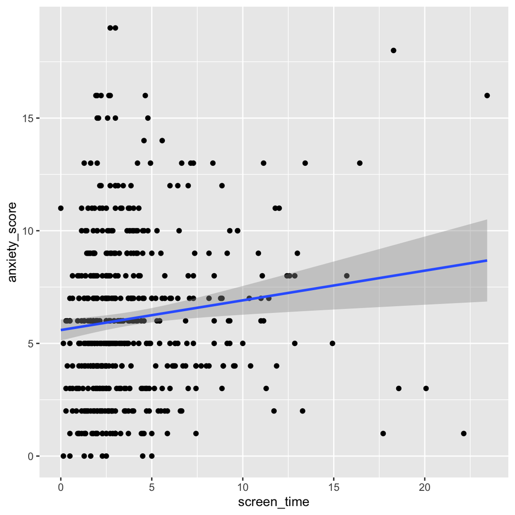

```r
mentalh %>%
  ggplot(aes(screen_time, anxiety_score)) +
  geom_point() +
  geom_smooth(method=lm)
```

**Explanation of the code**: We used `geom_point` to create a scatterplot. Then we used a plus symbol (`+`) and added `geom_smooth(method=lm)` to add the fitted line. By default, `geom_smooth` would try to fit a curvy line through your datapoints, but adding `method=lm` makes it a straight line.

**Explanation of the resulting plot** The plot above is just like the scatter plots we drew before, but adds the blue fitted line. The blue line shows the ‘line of best fit’. Ignore the shaded area for now (or add `geom_smooth(se=F)` to hide it).

**Code examples**

```r
library(psydata)
library(tidyverse)

# make a scatterplot with a fitted line overlaid
mentalh %>%
  ggplot(aes(screen_time, anxiety_score)) +
  geom_point() +
  geom_smooth(method=lm)
```

**Video Transcript**

We can make a scatterplot as previously:

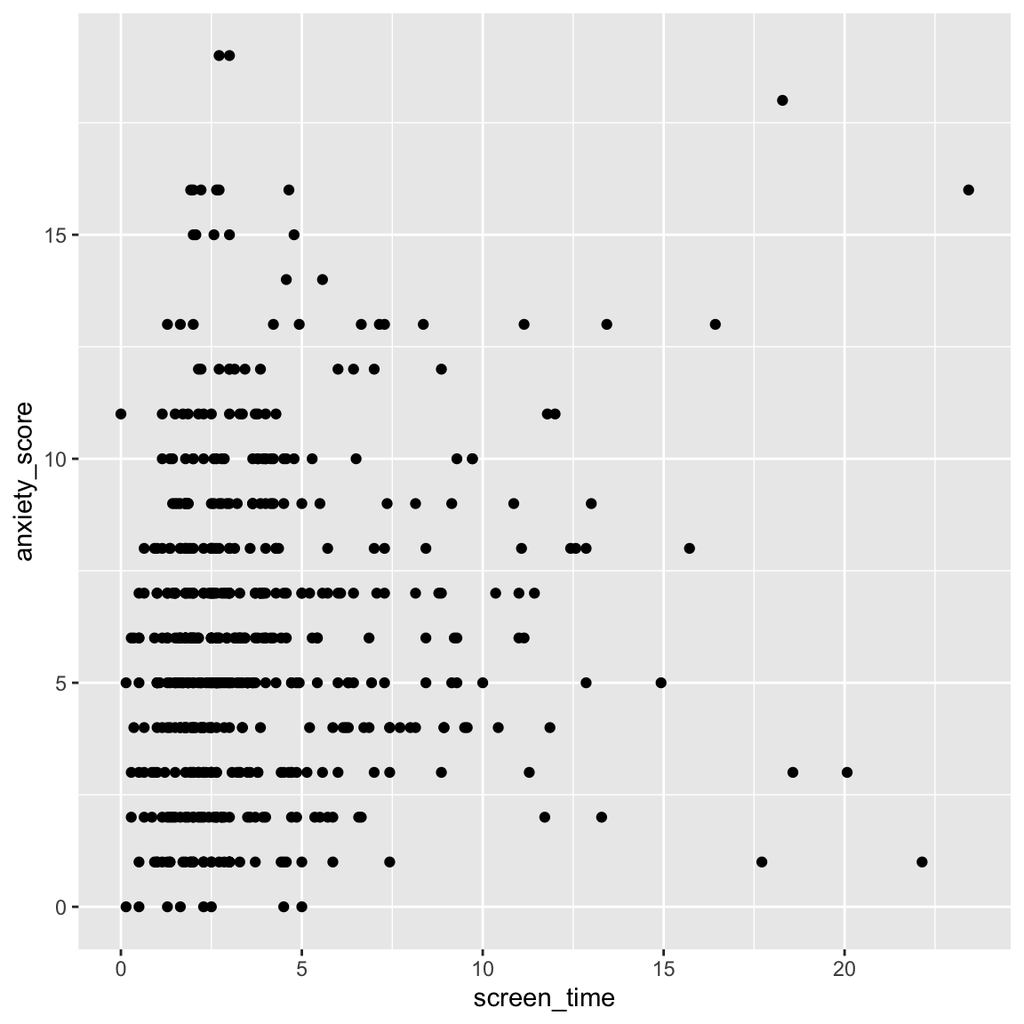

```r
mentalh %>%
  ggplot(aes(screen_time, anxiety_score)) +
  geom_point()
```

It’s common that we place variables that we consider outcomes on the y axis of the plot and predictors on the x-axis, as here.

If we want to add a line to the plot we can use the geom_smooth function:

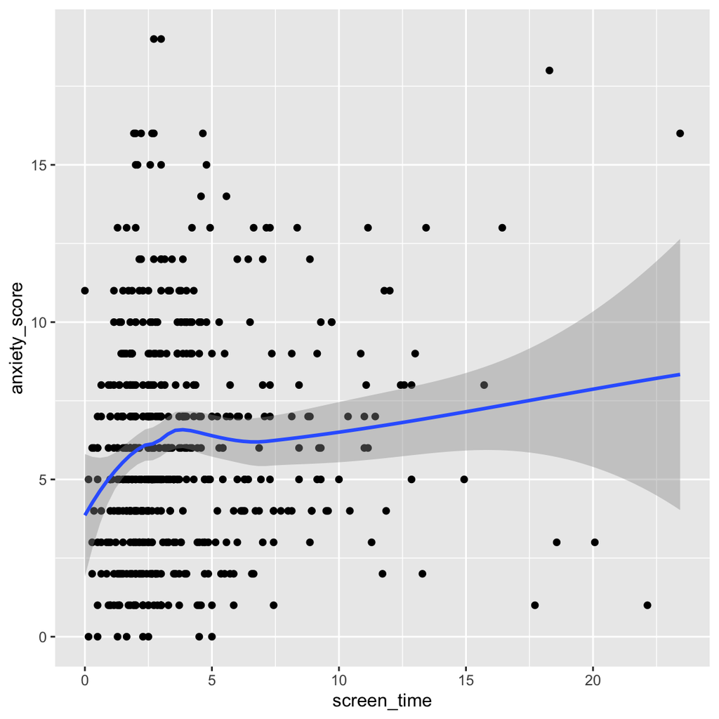

```r
mentalh %>%
  ggplot(aes(screen_time, anxiety_score)) +
  geom_point() +
  geom_smooth()
```

By default geom_smooth draws this wiggly line on the data. It uses uses a technique called Loess smoothing to draw the line.

It’s often quite useful to have the wiggly line because it shows the general trend in the relationship.

However in this case we want to see the linear line of best fit, because that will correspond with the simple linear regression we want to run.

To do that we just add `method=lm` to the geom_smooth part

So now we see this blue line which is the line of best fit — it’s the linear relationship between the predictor and the outcome.

You can ignore the shaded are for now — it shows the standard error of the line, which is a way of saying how confident we are about the predictions it makes. But, if it bugs you, you can add `se=F` to the call and it will hide it.